# p3_practice_mid_term_hes_e106

Gurdeep

21/10/2020

```r
rm(list = ls())

setwd("/cloud/project/practice_mid_term") # change to local directory before running

library(knitr)
library(onewaytests)
library(olsrr)
library(lmtest)
library(MASS)
library(ALSM)
pmq3 <- read.csv('PM Q3.csv')
head(pmq3)
```

```
##        y    x1   x2   x3   x4   x5    x6
## 1 148.23 13.37 0.66 0.81 3.81 0.45 10.65
## 2 160.38 10.96 0.63 0.64 2.85 0.41 15.47
## 3 170.41  9.22 0.62 0.81 3.34 0.48 15.70
## 4 208.65  9.65 0.90 1.01 3.34 0.50 76.65
## 5 146.03 11.72 0.64 0.90 3.18 0.47  9.39
## 6 180.19  9.33 0.62 1.48 4.33 0.71 23.38
```

```r
colnames(pmq3)
```

```
## [1] "y"  "x1" "x2" "x3" "x4" "x5" "x6"
```

```r
dim(pmq3)
```

```
## [1] 40  7
```

Perform one factor analysis by finding the best variable to explain Y. Fit one variable regression model with Y as a dependent variable against remaining variables, as an independent variable one at time. Choice the best variable explain Y and comment on the QQ plot and error vs. fitted values graph for the model assumptions.

```r
for (i in 2:(ncol(pmq3))) {
  print(paste("Regression with x",i-1))
  #print(pmq3[1,i])
  reg <- lm(y~pmq3[,i], data = pmq3)
  print(summary(reg))
}
```

```
## [1] "Regression with x 1"
##
## Call:
## lm(formula = y ~ pmq3[, i], data = pmq3)
##
## Residuals:
##     Min      1Q  Median      3Q     Max
## -81.198 -32.819   0.367  20.865  68.795
##
## Coefficients:
##             Estimate Std. Error t value Pr(>|t|)
## (Intercept)   95.405     22.346   4.269 0.000126 ***
## pmq3[, i]      7.069      2.093   3.377 0.001702 **
## ---
## Signif. codes:  0 '***' 0.001 '**' 0.01 '*' 0.05 '.' 0.1 ' ' 1
##
## Residual standard error: 37.09 on 38 degrees of freedom
## Multiple R-squared:  0.2309, Adjusted R-squared:  0.2106
## F-statistic: 11.41 on 1 and 38 DF,  p-value: 0.001702
##
## [1] "Regression with x 2"
##
## Call:
## lm(formula = y ~ pmq3[, i], data = pmq3)
##
## Residuals:
##     Min      1Q  Median      3Q     Max
## -76.504 -10.248   1.365  11.301  43.470
##
## Coefficients:
##             Estimate Std. Error t value Pr(>|t|)
## (Intercept)    44.86      13.86   3.237  0.00251 **
## pmq3[, i]     202.75      21.94   9.240 2.93e-11 ***
## ---
## Signif. codes:  0 '***' 0.001 '**' 0.01 '*' 0.05 '.' 0.1 ' ' 1
##
## Residual standard error: 23.47 on 38 degrees of freedom
## Multiple R-squared:  0.692,  Adjusted R-squared:  0.6839
## F-statistic: 85.38 on 1 and 38 DF,  p-value: 2.926e-11
##
```

[output cut: 64 more lines]

```
##
## Residuals:
##     Min      1Q  Median      3Q     Max
## -62.203 -16.180   1.339  18.162 109.671
##
## Coefficients:
##             Estimate Std. Error t value Pr(>|t|)
## (Intercept) 133.4907     8.8189  15.137  < 2e-16 ***
## pmq3[, i]     1.1692     0.2388   4.895 1.84e-05 ***
## ---
## Signif. codes:  0 '***' 0.001 '**' 0.01 '*' 0.05 '.' 0.1 ' ' 1
##
## Residual standard error: 33.12 on 38 degrees of freedom
## Multiple R-squared:  0.3867, Adjusted R-squared:  0.3706
## F-statistic: 23.96 on 1 and 38 DF,  p-value: 1.84e-05
```

As we see from above x2 has the best predictive value. We plot residuals below

```r
reg_p3_final <- lm(y~x2, data = pmq3)
summary(reg_p3_final)
```

```
##
## Call:
## lm(formula = y ~ x2, data = pmq3)
##
## Residuals:
##     Min      1Q  Median      3Q     Max
## -76.504 -10.248   1.365  11.301  43.470
##
## Coefficients:
##             Estimate Std. Error t value Pr(>|t|)
## (Intercept)    44.86      13.86   3.237  0.00251 **
## x2            202.75      21.94   9.240 2.93e-11 ***
## ---
## Signif. codes:  0 '***' 0.001 '**' 0.01 '*' 0.05 '.' 0.1 ' ' 1
##
## Residual standard error: 23.47 on 38 degrees of freedom
## Multiple R-squared:  0.692,  Adjusted R-squared:  0.6839
## F-statistic: 85.38 on 1 and 38 DF,  p-value: 2.926e-11
```

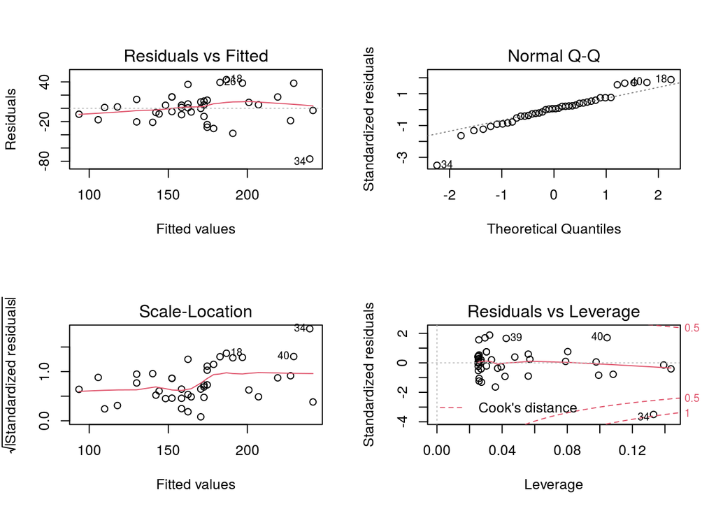

```r
ei_p3_final <- reg_p3_final$residuals

# plot residuals and other standard plots
old.par <- par(mfrow = c(2,2))
plot(reg_p3_final)
```

```r
old.par
```

```
## $mfrow
## [1] 1 1
```

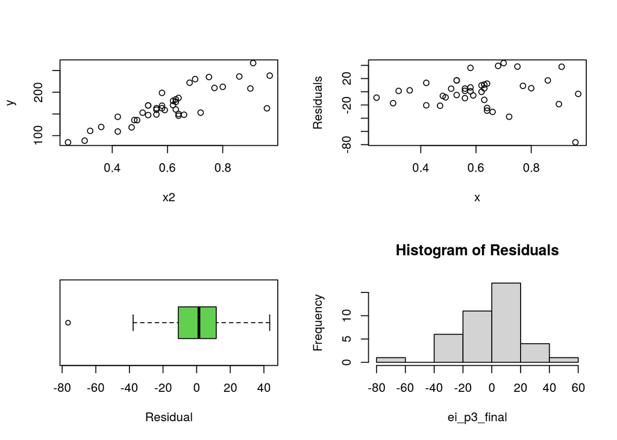

```r
newer.par = par(mfrow = c(2,2))
plot(pmq3$x2, pmq3$y, xlab = 'x2', ylab = 'y')
plot(pmq3$x2,ei_p3_final, xlab = 'x', ylab = 'Residuals')
boxplot(ei_p3_final, horizontal = TRUE, staplewax = 0.5, col = 3, xlab = 'Residual')
hist(ei_p3_final, main = 'Histogram of Residuals')
```

```r
newer.par
```

```
## $mfrow
## [1] 2 2
```

From above we see that x2 is the best independent variable with R2 of 0.69. It has F* = 85.38 and p-value = 2.926e-11 both of which convey significance.

The residual vs fitted plots show random pattern which is also reflected in the scatter plot and residual vs X plots.

The QQ plots are inline for 1SD; i.e. 68% of the values and the boxplot is also symmetrical except for a solitary outlier while a few outliers show up in the plots.

Hence, regression assumptions relating to linear relation, constant variance, independence and normality are satisfied.